# lydia part of pres

Lydia Myers

5/16/2021

```r
library(tidyverse)
library(factoextra)
```

```r
library(dplyr)
library(ggplot2)
```

## phylopca

Alright, so now lets talk about what we did with the package we created. Gabi and I are both primatologists, and we’re often interested in looking at the differences between different primates. PCA is a really helpful tool for analyses in our work, as we often have datasets with a whole lot of variables that would be difficult to analyze using non-PCA methods. The ideal type of analysis for our work is something that can deal with high dimensions of data, as well as easily look at differences between primates based on different levels of taxonomy, as it’s always helpful to know if variation is only at the species level, or if it’s also at the genus, or family, or even superfamily level.

So, we created some functions that do just that - PCAs specific to different taxonomic levels. We created two PCA functions, one runs a PCA on the sample at the family level, and one runs a PCA at the superfamily level. We then created two plotting functions that pair with the PCA functions, and show the output of the PCAs, grouping the values by either family or genus, depending on the taxonomic level of the PCA.

For demonstration of these functions, we used the Kamilar and Cooper dataset that we’ve worked with a bit in class this semester. The original dataset contained 40 variables with values for 213 primates. We pared this down, as a lot of the variables weren’t numeric and PCA only runs on numeric data, and ended up with 13 variables of the same number of primates. The original dataset included columns for family, genus and species of each primate, but we added on another superfamily column so we could analyze that as well. Let’s take a look at the data:

```r
d <- read_csv("data.csv", col_names = TRUE)
head(d)
```

```
## # A tibble: 6 x 17
##   Superfamily   Family     Genus     Species  Brain_Size_Specie… Mass_Dimorphism
##   <chr>         <chr>      <chr>     <chr>                 <dbl>           <dbl>
## 1 Cercopitheco… Cercopith… Allenopi… nigrovi…               58.0            1.93
## 2 Cercopitheco… Cercopith… Allocebus trichot…               NA              1.10
## 3 Ceboidea      Atelidae   Alouatta  belzebul               52.8            1.32
## 4 Ceboidea      Atelidae   Alouatta  caraya                 52.6            1.54
## 5 Ceboidea      Atelidae   Alouatta  guariba                51.7            1.27
## 6 Ceboidea      Atelidae   Alouatta  palliata               49.9            1.34
## # … with 11 more variables: MeanGroupSize <dbl>, InterbirthInterval_d <dbl>,
## #   WeaningAge_d <dbl>, MaxLongevity_m <dbl>, LitterSz <dbl>,
## #   Precip_Mean_mm <dbl>, Temp_Mean_degC <dbl>, HomeRange_km2 <dbl>,
## #   DayLength_km <dbl>, Territoriality <dbl>, Canine_Dimorphism <dbl>
```

Before we run a PCA, we need to get rid of the NA values in the dataset, as the PCA won’t run if they’re there

```r
d<-na.omit(d)
```

Now, lets look at the function we created to do a PCA on the data based on taxonomic family

```r
pca.family<-function(data, family.name){
  data<-na.omit(data)
  dfam<-filter(data, Family==family.name)
  pcafam<-prcomp(Filter(is.numeric, dfam), center=T, scale=T)
  return(summary(pcafam))
}
```

If you look at the function code, you can see that it automatically removes the NAs in the data, so you don’t need to do that. You can see that it then filters the data to include only the family which you specify with family.name = “”, and then runs a PCA using prcomp() on this subsetted data, and returns the summary. Let’s look at the function that does the same thing, but groups by superfamily instead.

```r
pca.superfamily<-function(data, superfamily.name){
  data<-na.omit(data)
  dsup<-filter(data, Superfamily==superfamily.name)
  pcasup<-prcomp(Filter(is.numeric, dsup), center=T, scale=T)
  return(summary(pcasup))
}
```

As you can see, it’s doing the same this as pca.family, but it’s subsetting by whichever superfamily you specify. Okay, now lets test out these two functions

```r
pca.family(d, "Cercopithecidae")
```

```
## Importance of components:
##                           PC1    PC2    PC3    PC4    PC5     PC6     PC7
## Standard deviation     2.1105 1.3682 1.2208 1.1836 1.1253 0.91862 0.72475
## Proportion of Variance 0.3426 0.1440 0.1146 0.1078 0.0974 0.06491 0.04041
## Cumulative Proportion  0.3426 0.4866 0.6013 0.7090 0.8064 0.87133 0.91173
##                            PC8     PC9    PC10    PC11    PC12    PC13
## Standard deviation     0.61734 0.59191 0.47482 0.35188 0.18928 0.17586
## Proportion of Variance 0.02932 0.02695 0.01734 0.00952 0.00276 0.00238
## Cumulative Proportion  0.94105 0.96800 0.98534 0.99487 0.99762 1.00000
```

```r
pca.superfamily(d, "Ceboidea")
```

```
## Importance of components:
##                           PC1    PC2    PC3     PC4    PC5     PC6     PC7
## Standard deviation     2.5838 1.5178 1.1419 1.00485 0.7614 0.58381 0.55308
## Proportion of Variance 0.5135 0.1772 0.1003 0.07767 0.0446 0.02622 0.02353
## Cumulative Proportion  0.5135 0.6907 0.7910 0.86870 0.9133 0.93952 0.96305
##                            PC8     PC9    PC10    PC11    PC12    PC13
## Standard deviation     0.43134 0.37882 0.28352 0.22692 0.12439 0.05895
## Proportion of Variance 0.01431 0.01104 0.00618 0.00396 0.00119 0.00027
## Cumulative Proportion  0.97736 0.98840 0.99458 0.99854 0.99973 1.00000
```

We also created two sister functions to the PCA functions that graph the analyses we just did. Let’s take a look at the function code.

```r
graph.family<-function(data, family.name){
  data<-na.omit(data)
  dfam<-filter(data, Family==family.name)
  pcafam<-prcomp(Filter(is.numeric, dfam), center=T, scale=T)
  fviz_pca_ind(pcafam, geom.ind = "point", pointshape = 21,
  pointsize = 2, fill.ind = dfam$Genus, invisible = "quali", palette = "pal8",
  addEllipses = T, legend.title="Genus") + labs(title = "PCA", x = "PC1", y = "PC2")
}

graph.superfamily<-function(data, superfamily.name){
  data<-na.omit(data)
  dsup<-filter(data, Superfamily==superfamily.name)
  pcasup<-prcomp(Filter(is.numeric, dsup), center=T, scale=T)
  fviz_pca_ind(pcasup, geom.ind = "point", pointshape = 21,
  pointsize = 2, fill.ind = dsup$Family, invisible = "quali", palette = "pal8",
  addEllipses = T, legend.title="Family") + labs(title = "PCA", x = "PC1", y = "PC2")
}
```

As you can see, the function actually runs the same PCAs that we ran in those last two functions, but then takes it a step further and graphs the first two PCs, and throws an ellipse around each genus in the first graph and each family in the second one. Lets test out these functions.

[output not shown]

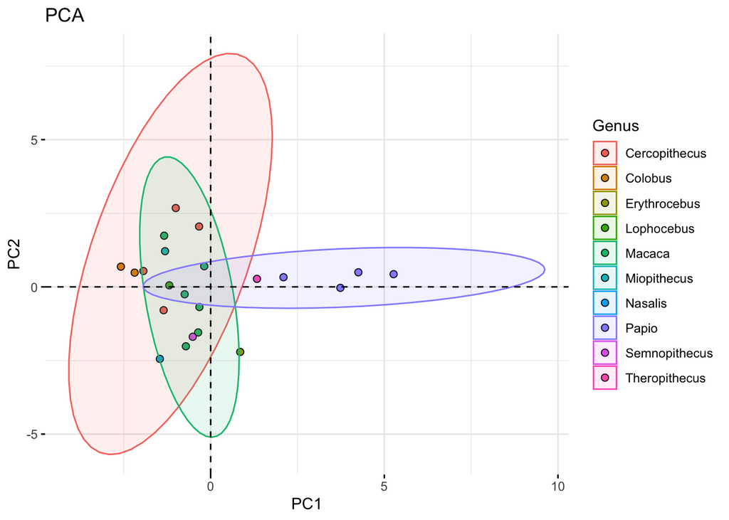

```r
graph.family(d, "Cercopithecidae")
```

```
## Too few points to calculate an ellipse
```

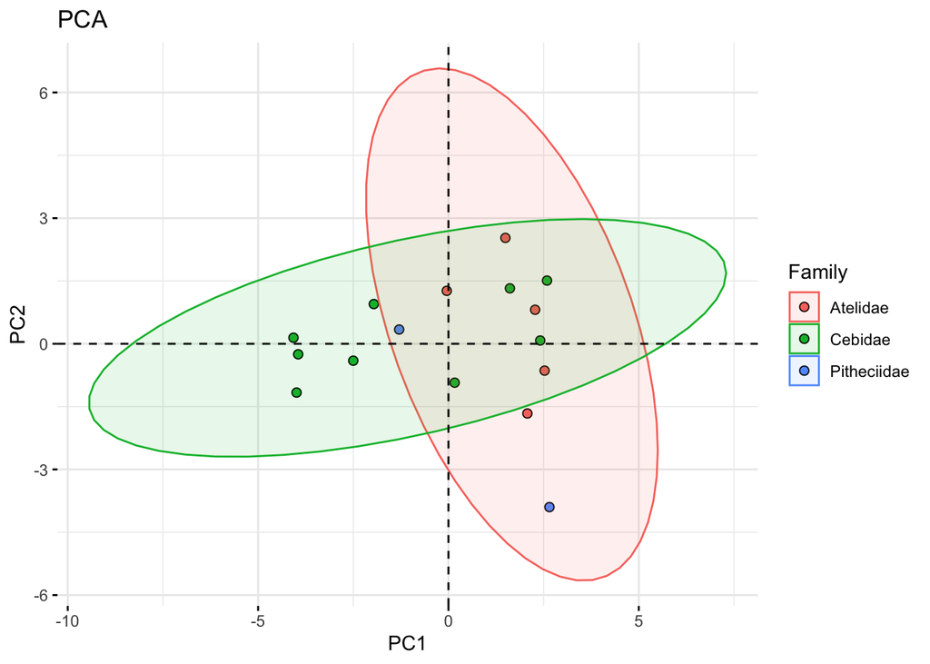

```r
graph.superfamily(d, "Ceboidea")
```

One of the really nice things about this function is that it’s customizible with ggplot functions. So, if I for example wanted to change the tile of the second graph, it’s super easy by using a + sign and some ggplot code.

```
## Too few points to calculate an ellipse
```

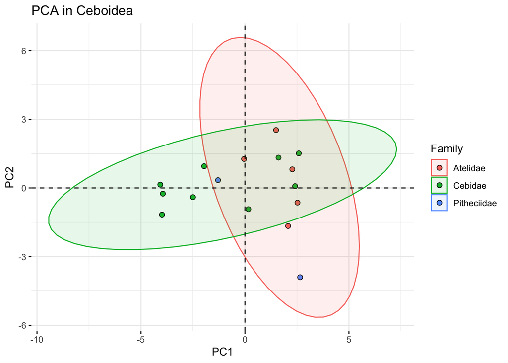

```r
graph.superfamily(d, "Ceboidea") + labs(title="PCA in Ceboidea")
```

The function provides a base graph that does what we need it to do, but it’s fully customizable so I could make it look however I want without having to change the function itself.

Our goal here was to create custom PCA functions that would allow for quick and easy PCA at different taxonomic levels, as well as a way to easily create aesthetically pleasing visualizations of those PCAs, and I think we reached that goal. So, does anyone have any questions?